# B03_One_Bit

| Abuzer Yakaryilmaz \| April 03, 2019 (updated) |
| --- |
| This cell contains some macros. If there is a problem with displaying mathematical formulas, please run this cell to load these macros. |

$ \newcommand{\bra}[1]{\langle #1|} $ $ \newcommand{\ket}[1]{|#1\rangle} $ $ \newcommand{\braket}[2]{\langle #1|#2\rangle} $ $ \newcommand{\dot}[2]{ #1 \cdot #2} $ $ \newcommand{\biginner}[2]{\left\langle #1,#2\right\rangle} $ $ \newcommand{\mymatrix}[2]{\left( \begin{array}{#1} #2\end{array} \right)} $ $ \newcommand{\myvector}[1]{\mymatrix{c}{#1}} $ $ \newcommand{\myrvector}[1]{\mymatrix{r}{#1}} $ $ \newcommand{\mypar}[1]{\left( #1 \right)} $ $ \newcommand{\mybigpar}[1]{ \Big( #1 \Big)} $ $ \newcommand{\sqrttwo}{\frac{1}{\sqrt{2}}} $ $ \newcommand{\dsqrttwo}{\dfrac{1}{\sqrt{2}}} $ $ \newcommand{\onehalf}{\frac{1}{2}} $ $ \newcommand{\donehalf}{\dfrac{1}{2}} $ $ \newcommand{\hadamard}{ \mymatrix{rr}{ \sqrttwo & \sqrttwo \\ \sqrttwo & -\sqrttwo }} $ $ \newcommand{\vzero}{\myvector{1\\0}} $ $ \newcommand{\vone}{\myvector{0\\1}} $ $ \newcommand{\vhadamardzero}{\myvector{ \sqrttwo \\ \sqrttwo } } $ $ \newcommand{\vhadamardone}{ \myrvector{ \sqrttwo \\ -\sqrttwo } } $ $ \newcommand{\myarray}[2]{ \begin{array}{#1}#2\end{array}} $ $ \newcommand{\X}{ \mymatrix{cc}{0 & 1 \\ 1 & 0} } $ $ \newcommand{\Z}{ \mymatrix{rr}{1 & 0 \\ 0 & -1} } $ $ \newcommand{\Htwo}{ \mymatrix{rrrr}{ \frac{1}{2} & \frac{1}{2} & \frac{1}{2} & \frac{1}{2} \\ \frac{1}{2} & -\frac{1}{2} & \frac{1}{2} & -\frac{1}{2} \\ \frac{1}{2} & \frac{1}{2} & -\frac{1}{2} & -\frac{1}{2} \\ \frac{1}{2} & -\frac{1}{2} & -\frac{1}{2} & \frac{1}{2} } } $ $ \newcommand{\CNOT}{ \mymatrix{cccc}{1 & 0 & 0 & 0 \\ 0 & 1 & 0 & 0 \\ 0 & 0 & 0 & 1 \\ 0 & 0 & 1 & 0} } $ $ \newcommand{\norm}[1]{ \left\lVert #1 \right\rVert } $

## One Bit

In daily life, we use decimal number system. It is also called base-10 system, because we have 10 digits:

$ 0,~1,~2,~3,~4,~5,~6,~7,~8, \mbox{ and } 9 $.

In computer science, on the other hand, the widely used system is binary, which has only two digits:

$ 0 $ and $ 1 $.

One bit (or binary digit) is the basic unit of information used in computer science.

It can also be seen as the smallest "useful" memory unit, which has two states named 0 and 1.

One bit can be in (or store) either 0 or 1.

### Four operators

How many different operators can be defined on a single bit?

*An operator, depending on the current state of the bit, updates the state of bit (the result may be the same state).*

We can apply four different operators to a single bit:

1. Identity: $ I(0) = 0 $ and $ I(1) = 1 $
2. Negation: $ NOT(0) = 1 $ and $ NOT(1) = 0 $
3. Constant (Zero): $ ZERO(0) = 0 $ and $ ZERO(1) = 0 $
4. Constant (One): $ ONE(0) = 1 $ and $ ONE(1) = 1 $

The first operator is called IDENTITY, because it does not change the content/value of the bit.

The second operator is named NOT, bacause it negates (flips) the value of bit.

*Remark that 0 and 1 also refer to Boolean values False and True, respectively, and, False is the negation of True, and True is the negation of False.*

The third (resp., fourth) operator returns a constant value 0 (resp., 1), whatever the input is.

### Table representation

Let's represent the transition of each operator by a table.

In each table,

- the header (first row) represents the initial values,
- the first column represents the final values,
- we use 1 if there is a transition between two values, and,
- we use 0 if there is no transition between two values.

The table representation of the identity operator is given below:

$ I = \begin{array}{c|cc} & \mathbf{0} & \mathbf{1} \\ \hline \mathbf{0} & 1 & 0 \\ \mathbf{1} & 0 & 1 \end{array} $

The values in **bold** are the initial and final values of the bits. The non-bold values represent the transitions.

- The top-left non-bold 1 represents the transtion $ 0 \rightarrow 0 $.
- The bottom-right non-bold 1 represents the transtion $ 1 \rightarrow 1 $.
- The top-right non-bold 0 means that there is no transition from 1 to 0.
- The bottom-left non-bold 0 means that there is no transition from 0 to 1.

Similarly, we can represent the other operators as below:

[output not shown]

### Task 1

Convience yourself with the correctness of each table.

### Reversibility and Irreversibility

After applying Identity or NOT operator, we can easily determine the initial value by checking the final value.

- In the case of Identity operator, we simply say the same value.
- In the case of NOT operator, we simply say the other value, i.e., if the final value is 0 (resp., 1), then we say 1 (resp., 0).

However, we cannot know the initial value by checking the final value after applying ZERO or ONE operator.

Based on this observation, we can classify the operators into two types: *Reversible* and *Irreversible*.

- If we can recover the initial value(s) from the final value(s), then the operator is called reversible like Identity and NOT operators.
- If we cannot know the initial value(s) from the final value(s), then the operator is called irreversible like ZERO and ONE operators.

**This classification is important, because, as will be seen later, the quantum evolution operators are reversible.**

The identity operator does not have any affect on the computation, and so it is not interesting.

But we will widely use NOT operator in our quantum algorithms.

### Our first quantum circuit

For our quantum programs, we will design quantum circuits.

As a warm-up example, here we design a circuit with a single quantum bit.

We also highlight the details on designing quantum circuits along with our codes.

```python
#
# A quantum circuit is composed by quantum and classical bits.
#

# here are the objects that we use to create a quantum circuit in qiskit
from qiskit import QuantumRegister, ClassicalRegister, QuantumCircuit

# we use a quantum register to keep our quantum bits.
qreg =  QuantumRegister(1) # in this example we will use a single quantum bit

# To get an information from a quantum bit, it must be measured. (More details will appear.)
#     The measurement result is stored classically.
#     Therefore, we also use a classical regiser with classical bits
creg = ClassicalRegister(1) # in this example we will use a single classical bit

# now we can define our quantum circuit
# it is composed by a quantum and a classical register
mycircuit = QuantumCircuit(qreg,creg)

# we apply operators on quantum bits
# operators are also called as gates
# we apply NOT operator represented as "x" in qiskit
# operator is a part of the circuit, and we should specify the quantum bit as its parameter
mycircuit.x(qreg[0]) # (quantum) bits are enumerated starting from 0
# NOT operator or x-gate is applied to the first qubit of the quantum register

# let's run our codes until now, and then draw our circuit
print("Everything looks fine, let's continue ...")
```

```
Everything looks fine, let's continue ...
```

```python
# in qiskit, the circuit object has a method called "draw"
# it can take different parameters
# we use "matplotlib" -- the first parameter
# we also order the bits by reversing, which helps us to read the output -- the second parameter

# let's draw our circuit now
mycircuit.draw(output='mpl',reverse_bits=True)

# re-execute this cell if you DO NOT see the circuit diagram
```

[output not shown]

**Congratulations!** if you see your diagram :-)

*Remak*: Qiskit has its own counters to enumerate the objects ($ q2_0 $, $ c2_0 $, etc.).

- They might be useful for debugging, but currently you can simply discard this part.
- You may also notice that when you re-run the same codes, the index of objects will be increased.

The value of the quantum bit is 0 at the beginning. Technically, we denote is as $ \ket{0} $, called *ket*-notation.

The value of the classical bit is also 0 at the beginning.

Classical or quantum, each bit is represented as a straight line. You may think of it as a wire.

The x-gate is shown as a square.

The value of the quantum bit is expected to be $ \ket{1} $ after the operator.

Let's measure the first qubit (define a mesurement operator), and then execute our circuit and see the result.

```python
# measurement is defined by associating a quantum bit to a classical bit
mycircuit.measure(qreg[0],creg[0])
# the result will be stored in the classical bit

print("Everything looks fine, let's continue ...")
```

```
Everything looks fine, let's continue ...
```

```python
# let's draw the circuit again to see how the measurement is defined
mycircuit.draw() # we use now ASCII art version

# reexecute me if you DO NOT see the circuit diagram
```

```
         ┌───┐┌─┐
q0_0: |0>┤ X ├┤M├
         └───┘└╥┘
 c0_0: 0 ══════╩═
```

```python
# we are done with designing of our circuit
# now we can execute it
# we execute quantum circuits many times (WHY?)

# we use method "execute" and object "Aer" from qiskit library
from qiskit import execute, Aer

# we create a job object for execution of the circuit
# there are three parameters
#     1. mycircuit
#     2. beckend on which it will be executed: we will use local simulator
#     3. how_many_times will it be executed, let's pick it as 1024
job = execute(mycircuit,Aer.get_backend('qasm_simulator'),shots=1024)

# we can get the result of the outcome as follows
counts = job.result().get_counts(mycircuit)
print(counts)

# usually quantum programs produce probabilistic outcomes
```

```
{'1': 1024}
```

We expect to see 1 in each execution, and so the output should be $ \{\mbox{'1'}:~1024\} $.

That is, the outcome 1 is measured 1024 times.

*The output is composed by pairs, and each pair showing the measurement outcome and how many times it was measured.*  
*For example, if the output is $ \{\mbox{'0': 500, '1': 524}\} $, then we know that the outcome 0 is measured 500 times and the outcome 1 is measured 524 times.*

*Quantum programs usually give probabilistic outcomes.*

Therefore, we should execute them many times to get more reliable outcomes. </b></i>

### My second quantum circuit

Let's create a quantum circuit with four quantum bits.

We use almost the same code with small modifications.

Our comments explain only the modifications.

```python
#
# My second quantum circuit
#

# we import all at once
from qiskit import QuantumRegister, ClassicalRegister, QuantumCircuit, execute, Aer

# we will use 4 quantum bits and 4 classical bits
qreg2 =  QuantumRegister(4)
creg2 = ClassicalRegister(4)

mycircuit2 = QuantumCircuit(qreg2,creg2)

# We will apply x-gate to the first quantum bit twice
mycircuit2.x(qreg2[0])
mycircuit2.x(qreg2[0])

# We will apply x-gate to the fourth quantum bit once
mycircuit2.x(qreg2[3])

# We will apply x-gate to the third quantum bit three times
mycircuit2.x(qreg2[2])
mycircuit2.x(qreg2[2])
mycircuit2.x(qreg2[2])

# We will apply x-gate to the second quantum bit four times
mycircuit2.x(qreg2[1])
mycircuit2.x(qreg2[1])
mycircuit2.x(qreg2[1])
mycircuit2.x(qreg2[1])

# if the sizes of quantum and classical registers are the same, we can define measurements with a single line of code
mycircuit2.measure(qreg2,creg2)
# then each quantum bit and classical bit is associated with respect to their indices

# let's run our codes until now, and then draw our circuit

print("Everything looks fine, let's continue ...")
```

```
Everything looks fine, let's continue ...
```

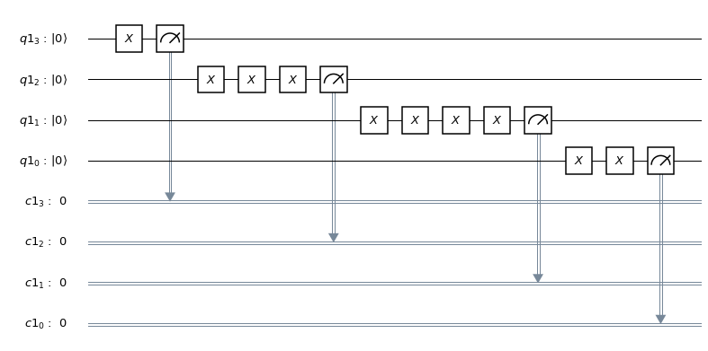

```python
mycircuit2.draw(output='mpl',reverse_bits=True)
# re-execute me if you DO NOT see the circuit diagram
```

### Task 2

Guess the outcome by checking the circuit.

Then, compare your guess with the result obtained after executing our circuit 500 times.

```python
job = execute(mycircuit2,Aer.get_backend('qasm_simulator'),shots=500)
counts = job.result().get_counts(mycircuit2)
print(counts)
```

```
{'1100': 500}
```

### An important technical note:

In Qiskit the outcomes are started to be read from the higher indices $$ creg[3],~creg[2],~creg[1],~creg[0] $$ and so, reversing the diagram would help us when reading the outcome(s).

### Reverse the output

Let's write a method to print the reverse the outcomes whenever it is needed.

```python
def print_outcomes(counts): # takes a dictionary variable
    for outcome in counts: # for each key-value in dictionary
        reverse_outcome = ''
        for i in outcome: # each string can be considered as a list of characters
            reverse_outcome = i + reverse_outcome # each new symbol comes before the old symbol(s)
        print(reverse_outcome,"is observed",counts[outcome],"times")

job = execute(mycircuit2,Aer.get_backend('qasm_simulator'),shots=1024)
counts = job.result().get_counts(mycircuit2) # counts is a dictionary object in python
print_outcomes(counts)
```

```
0011 is observed 1024 times
```

### Pick a random number

In your first circuit design task, you will be asked to apply x-gate to randomly picked quantum bits.

Here is one of the methods to pick a random number in python.

```python
from random import randrange
n = 20
r=randrange(n) # pick a number from the list {0,1,...,n-1}
print(r)

# test this method by using a loop
for i in range(10):
    print(randrange(n))
```

```
15
12
6
14
8
1
16
6
14
15
16
```

### Task 3

Design a quantum circuit with 10 quantum bits and 10 classical bits.

For each quantum bit, flip a coin by python, and apply x-gate if the outcome is head.

Measure your quantum bits.

Execute your circuit 128 times.

Repeat this task as much as you want, and enjoy your random choices.

[output not shown]

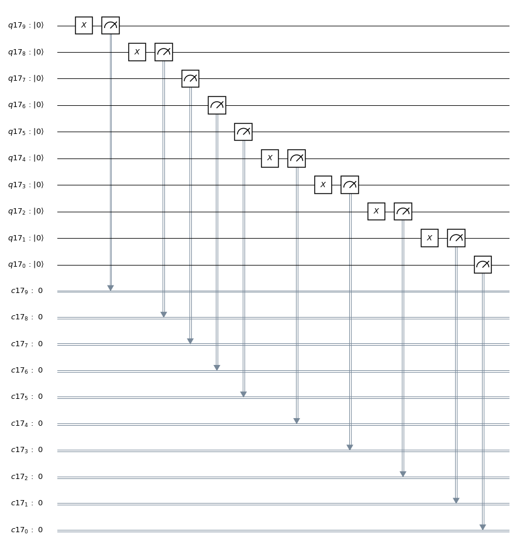

```python
#
# your solution is here
#
# Quantum register with 10 bits
qreg3 =  QuantumRegister(10)
creg3 = ClassicalRegister(10)

# Construct the quantum circuit
mycircuit3 = QuantumCircuit(qreg3,creg3)
qubits_idx=[]

# Randomly iterate through bits
for i in range(10):
    if(randrange(2) == 1): # 1 is the head
        mycircuit3.x(qreg3[i])
        qubits_idx.append(i)

# Measure the results
mycircuit3.measure(qreg3,creg3)
job = execute(mycircuit3,Aer.get_backend('qasm_simulator'),shots=128)
counts = job.result().get_counts(mycircuit3)
print_outcomes(counts)

# display counts and randomly picked index
print(counts)
print(picked_qubits_idx)
mycircuit3.draw(output='mpl',reverse_bits=True)
```

click for our solution